# Students’ Academic Performance Analysis

**Foundations of Data Science and Lab — A.Y. 2024/2025** **Hassan Ahmed**

Dataset: *Students Performance in Exams* (Kaggle)

# Motivation

**Goal:** understand which factors are associated with students’ exam performance.

**Research questions:**

- How are math scores distributed?
- Are there differences by gender?
- Does test preparation help?
- Are subjects related (math, reading, writing)?
- Can we predict math score from other variables?

# Dataset

**Source:** Kaggle — *Students Performance in Exams*

**Rows:** 1000 students **Variables:**

- Gender
- Race/ethnicity (group A–E)
- Parental level of education
- Lunch (standard vs free/reduced)
- Test preparation course (none vs completed)
- Scores: math, reading, writing (0–100)

**Target for modelling:** math_score

# Data preparation

- Renamed columns for readability (e.g., `math score` → `math_score`)
- Checked missing values (none in this dataset)
- Created an additional feature:
  - `average_score = (math + reading + writing) / 3`

**Why:** easier analysis, cleaner plots, and modelling.

# Exploratory Data Analysis (EDA)

We explore distributions and group differences, and we inspect relationships among subjects.

## Distribution of Math Scores

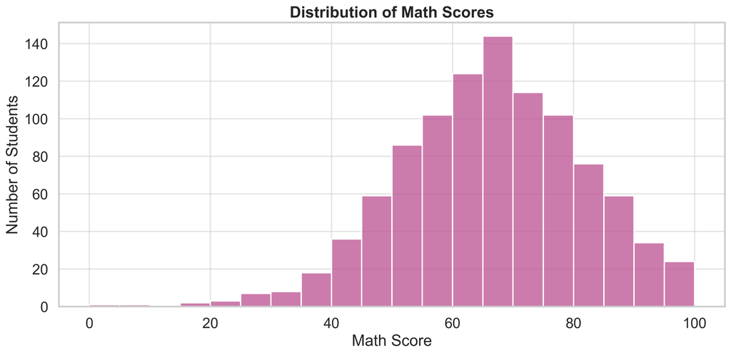

Most students score in the middle-to-upper range, with only a smaller number of low outliers. The distribution looks fairly balanced overall.

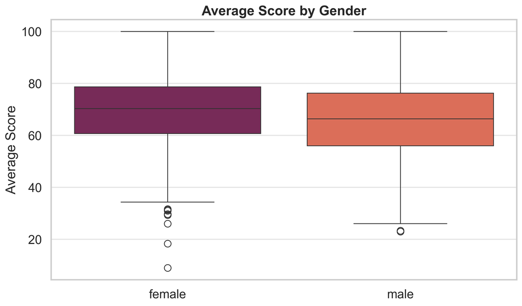

The distributions overlap heavily, with only small differences in central tendency. Gender alone does not seem to be the main driver of performance.

## Lunch Type and Performance

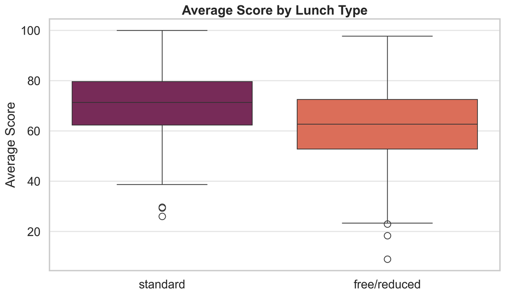

## Effect of Test Preparation

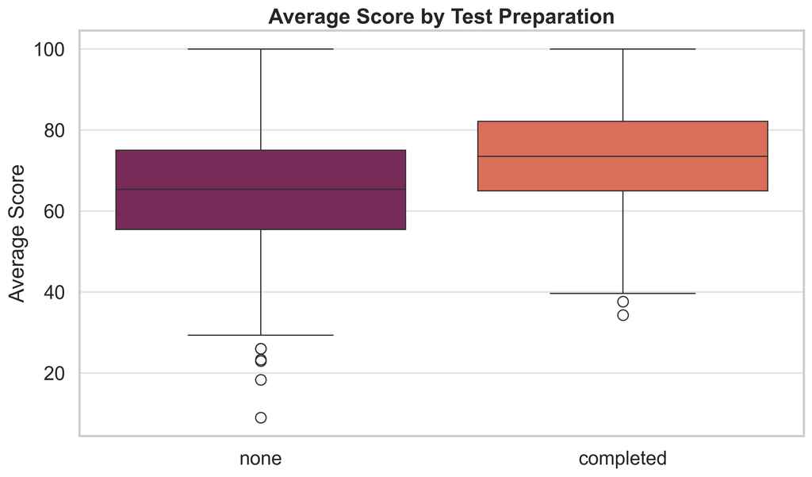

Students who completed the prep course score noticeably higher on average. Structured preparation appears to improve academic performance.

## Correlation Between Subject Scores

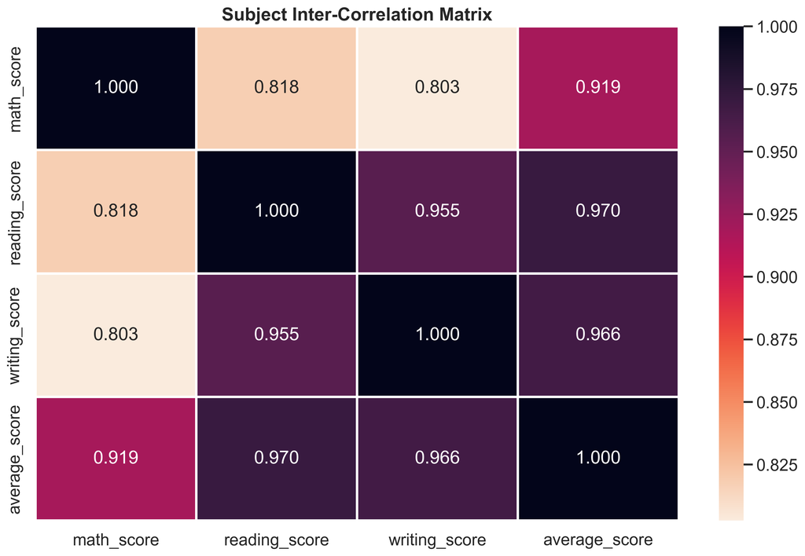

Reading and writing are strongly related, and math is also positively associated with both. Subject performance tends to move together.

## Score Density Overview

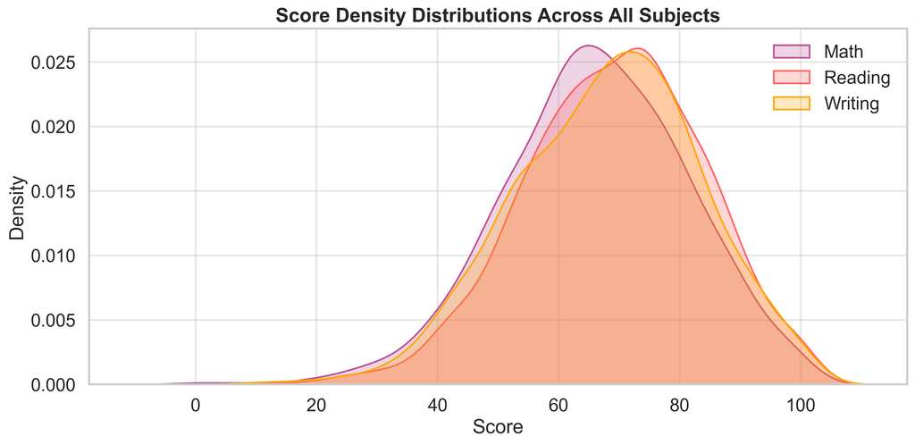

Most students fall near the center of the score range, with a smaller lower tail. The distribution is fairly smooth and not strongly skewed.

## Parental Education and Student Performance

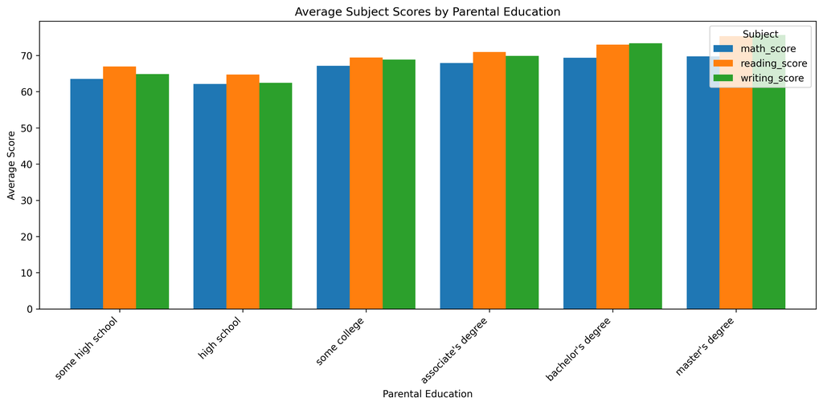

Higher parental education is associated with better average scores. This suggests that the home environment influences academic outcomes.

## Parental Education and Lunch

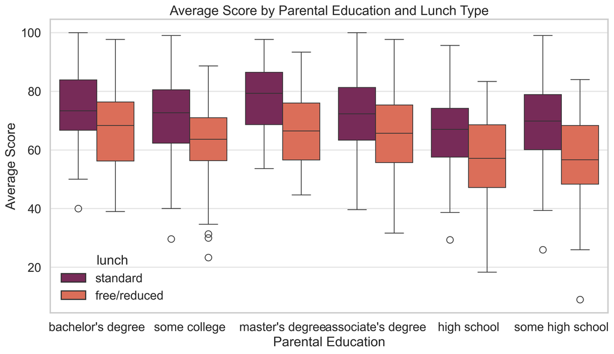

## Parental Education and Test Preparation

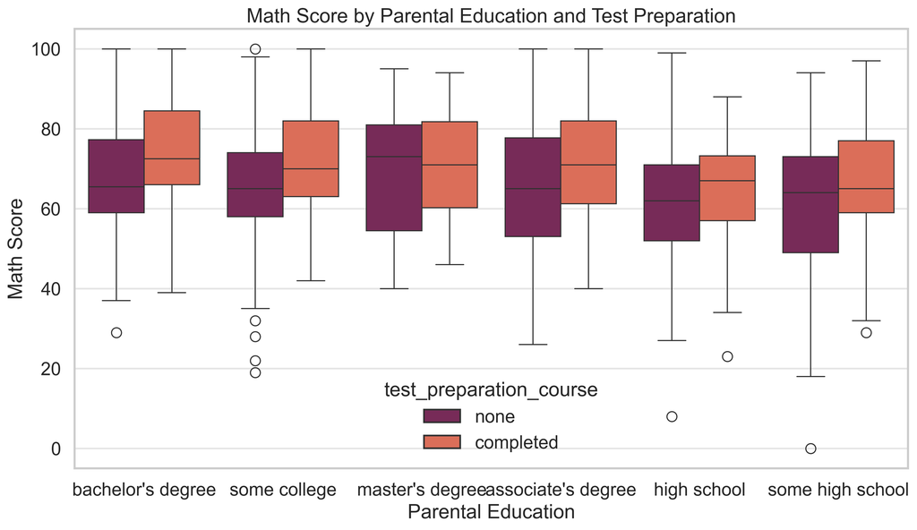

## Gender and Lunch Combined

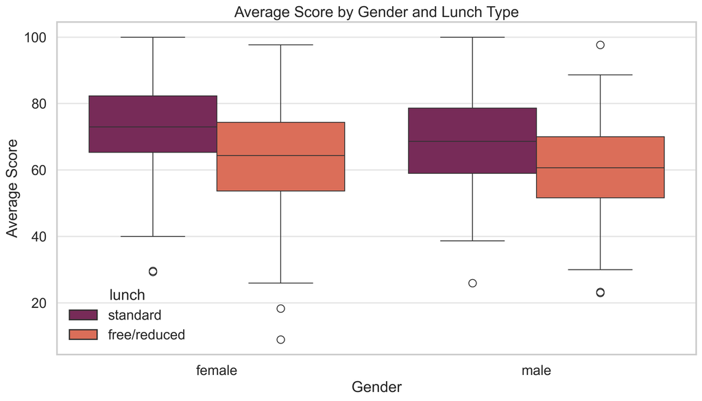

The gender gap is small compared with the effect of lunch type. Students with standard lunch perform better, regardless of gender.

## Math vs Reading by Lunch

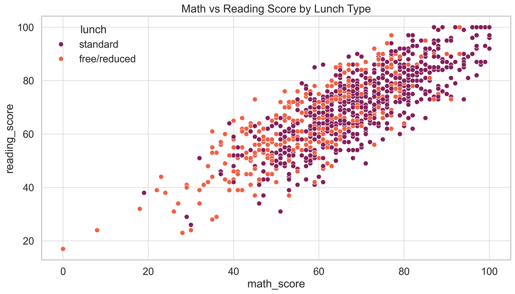

## Math vs Reading by Parental Education

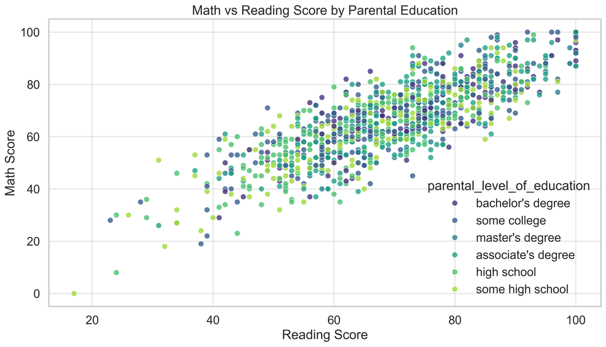

The relationship stays strong across education levels, while higher parental education is linked to better scores. Family background seems to shape performance.

## Math vs Writing by Test Preparation

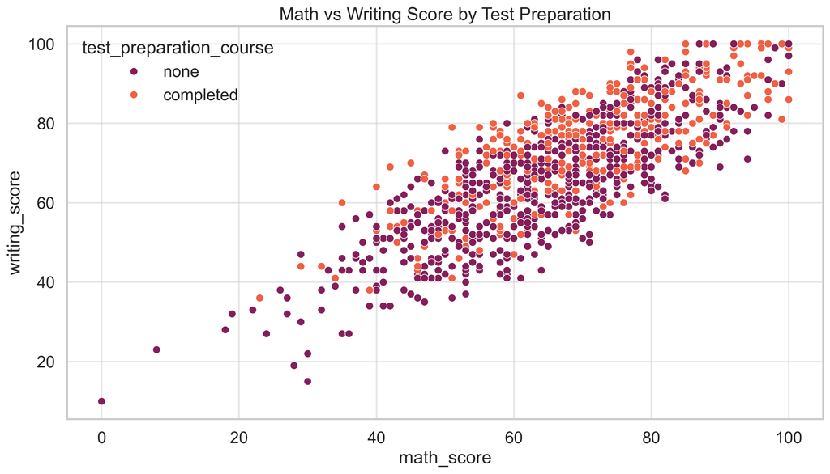

Students who completed prep generally perform better in both math and writing. The benefit appears across multiple subjects, not just one.

## Correlation Matrix Overview

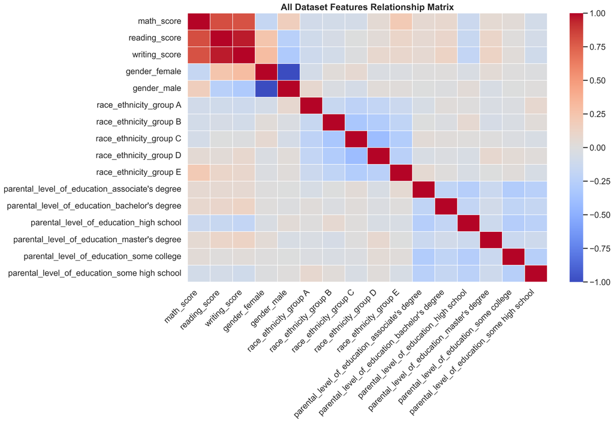

The subject scores are strongly related, while background variables are weaker but still meaningful. Overall, the pattern is consistent across the dataset.

## Parental Education Check

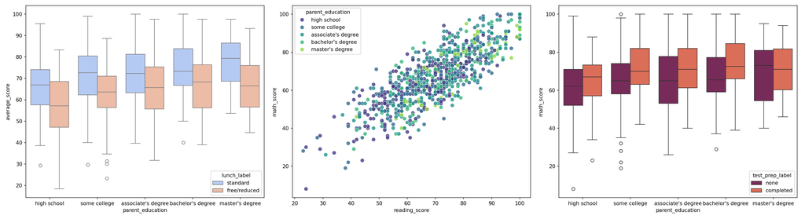

This check confirms that the parental education trend is consistent across the data. The pattern remains stable when viewed from another angle.

## All Features Correlation

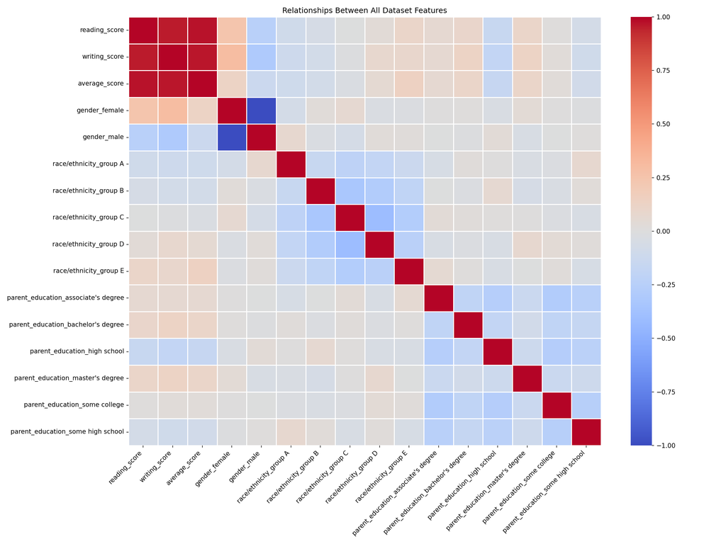

The strongest relationships are among the score variables; background features matter too, but less strongly. This supports the broader pattern of academic performance.

# Conclusions

Overall, students perform best when they combine strong preparation with supportive background conditions.

**Key results:**

- Math scores are mostly centered in the middle-to-upper range.
- Test preparation is associated with higher scores.
- Standard lunch and higher parental education are linked to better performance.
- Reading and writing are strongly related, and all subjects move together.

**Limitations:**

- The data is observational, so we can identify associations but not causation.
- Important factors such as study time and school quality are not included.

# Thank You

Questions?